# Estimating cue rates for animals with silence-bout sound patterns

Supplementary material

Tiago A. Marques, Sónia Coelho, Ana I. Leal

17 August 2023

# Introduction

This file is a supplement to the paper “Estimating cue rates for animals with silence-bout sound patterns” by Tiago A. Marques, Sónia Coelho and Ana I. Leal. Details about the methods are presented in the main document for the paper.

If this file is compiled first, it will as a final side effect to save an R workspace, which can then be loaded upfront on the manuscript file to recreate all the figures and statistics reported on the paper.

Here we read the data from the focal follows

The times of calls are recorded as the fraction of the day since the beginning of the day, at midnight, so we recode these fractions of the day to represent seconds.

```r
#recode inter-event-intervals (iei) to be in seconds
cantos$iei<-cantos$iei*((24*60*60))
```

We pre-process the data to get which of the events are inter-sound-intervals. Most of those records for which `Event=call` correspond indeed to $isi$’s, but the notable exception are:

- those which end with a `call`, which will have no `iei`, and
- those for focal follows not initiated at a sound, labelled as `Event=rec.start`. For these, the first `iei` corresponds to a time between the start of the focal follow and the first call produced, and hence must be removed for when modelling $isi$’s.

To account for both of these we create a new column labelled `isi` with an indicator that takes the value 1 is the `iei` corresponds to an `isi`, and 0 otherwise. Only those $iei$ with `isi=TRUE` will be considered for modelling the $isi$ components

```r
cantos$isi<-1
#removing iei's that are not isi's
#those not calls are not isi's
cantos$isi[cantos$Event!="call"]<-0
#those that are calls but the end of the ofcal follow is with a call are 0 (these always happen with iei=NA)
cantos$isi[is.na(cantos$iei)]<-0
#those for focal follows not initiated at a sound, labelled as `Event=rec.start`
cantos$isi[which(cantos$Event=="rec.start")+1]<-0
```

summaries by bird:

```r
#compute cue rates per animal etc
#cr is cue rate per minute
# sounds: number of sounds produced
# n: number of records, at most "sounds"+2 (if sac=0 and eac=0), at least "sounds" (if sac=1 and eac=1)
# start1: recording start and first sound if sac=1
# start2: the first sound if sac=0
# end1: recording end and last sound if eac=1
# end2: the last sound if eac=0
# dur1: the "standard" duration as in end time minus start time (in minutes)
# cr1: the conventional cue rate, number of sounds / duration
# sac: the indicator of whether recording started with a sound
# eac: the indicator of whether recording ended with a sound
crs.by.indiv<-cantos %>% group_by(Indiv) %>% summarise(sounds=sum(Event=="call"),n = n(),start1=min(Time),start2=Time[2],end1=max(Time),end2=sort(Time,decreasing =TRUE)[2],dur1=25*60*(end1-start1),cr1=sounds/dur1,sac=sac[1],eac=eac[1])
#adding dur2: the duration from the first to the last sound produced, in minutes
#this will be required for our suggested estimator
start<-with(crs.by.indiv,ifelse(sac==1,start1,start2))
end<-with(crs.by.indiv,ifelse(eac==1,end1,end2))
crs.by.indiv$dur2<-25*60*(end-start)
```

```r
#the isi times
st <- cantos %>% drop_na("isi")
```

We have a total of 1057 times of sound production obtained from focal follows of 47 individuals.

Individuals were followed on average for 6.12 minutes, ranging from 0.57 to 11.75 minutes. The distribution of these focal follow times is shown below:

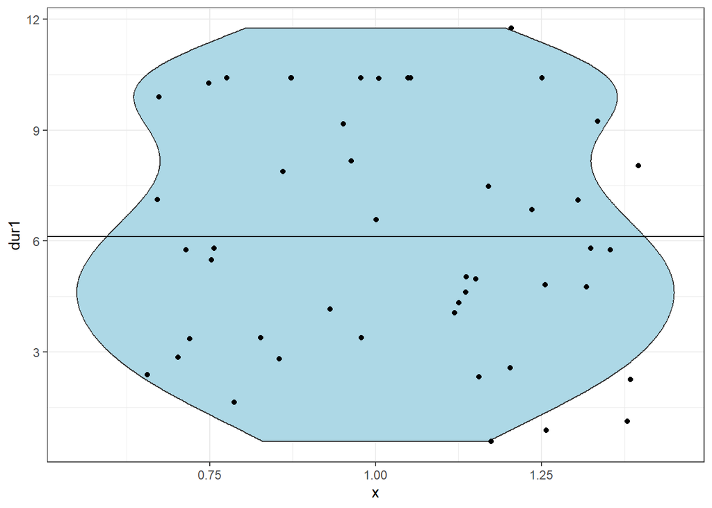

```r
ggplot(crs.by.indiv,aes(x=1,y=dur1),fill="lightblue")+
  theme_bw()+geom_violin(fill="lightblue")+geom_jitter()+geom_hline(yintercept=mean(crs.by.indiv$dur1))
```

We can take a look at the data.

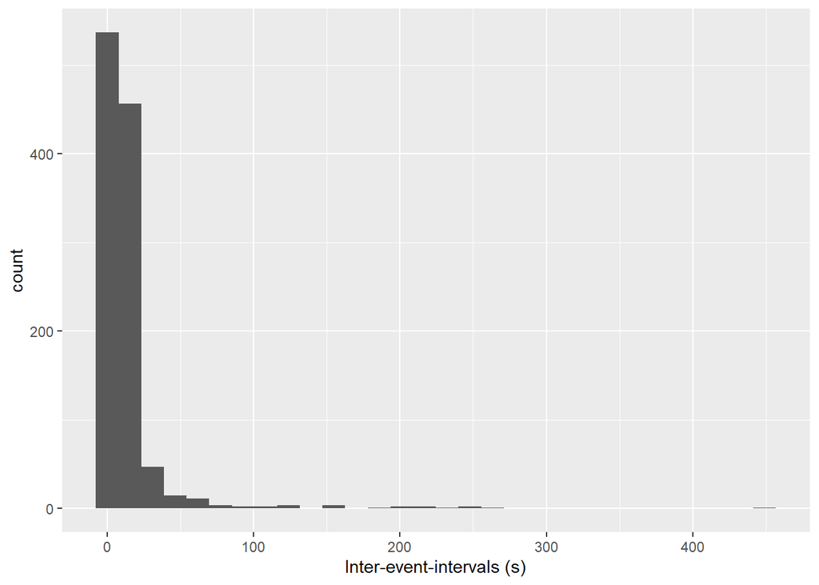

```r
ggplot(cantos, aes(x=iei)) + geom_histogram() + xlab("Inter-event-intervals (s)")
```

```r
#hist(cantos$iei, breaks = 20, main="", xlab="Inter-event-intervals (s)")
```

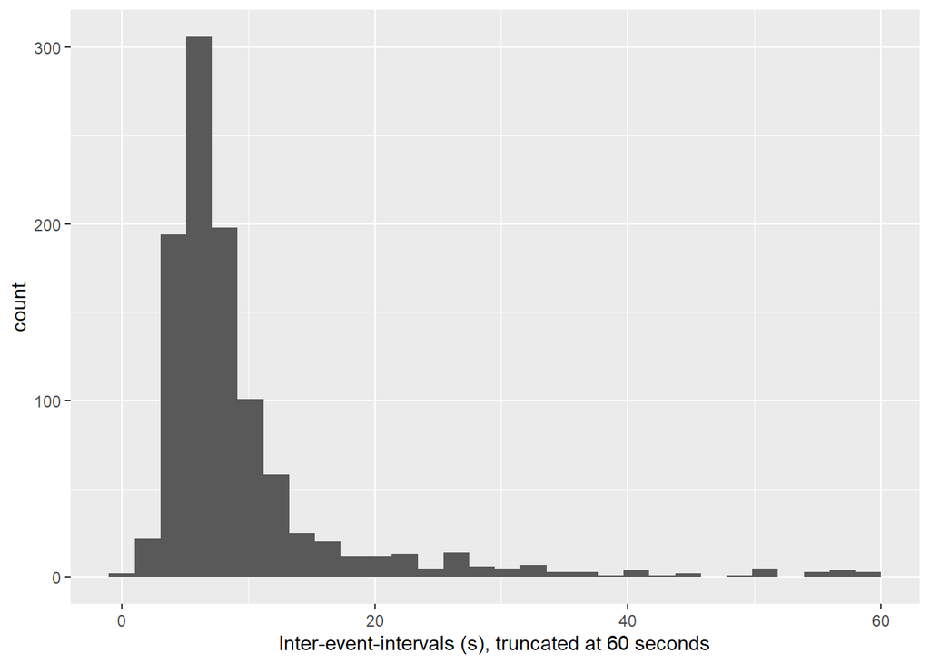

```r
#hist truncated for iei <60s
ggplot(cantos[(cantos$isi==1 & cantos$iei<60),], aes(x=iei)) + geom_histogram() + xlab("Inter-event-intervals (s), truncated at 60 seconds")
```

```r
#hist(cantos$iei[(cantos$isi==1 & cantos$iei<60),], main="", xlab="Inter-event-intervals (s), truncated at 60 seconds")
```

The per animal cue rates are shown below:

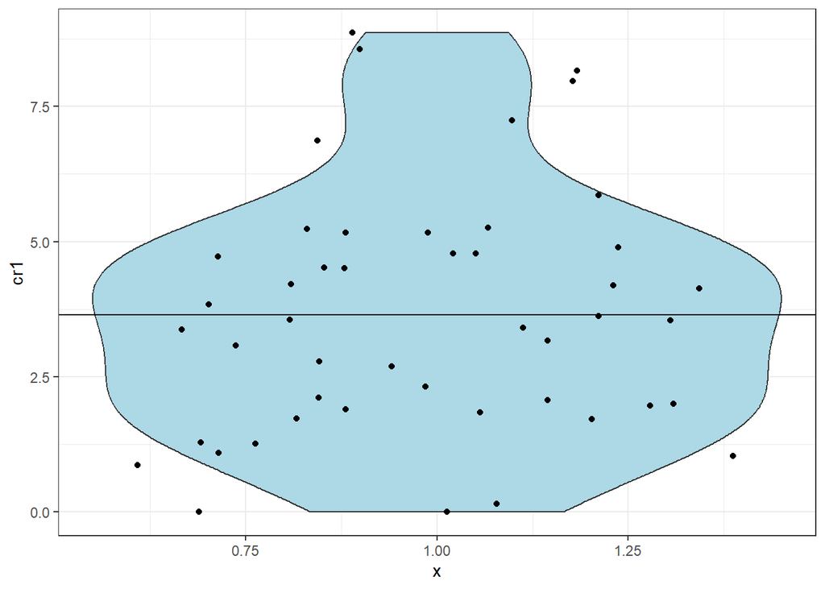

```r
ggplot(crs.by.indiv,aes(x=1,y=cr1),fill="lightblue")+
  theme_bw()+geom_violin(fill="lightblue")+geom_jitter()+geom_hline(yintercept=mean(crs.by.indiv$cr1))
```

```r
ci.cr1<-t.test(crs.by.indiv$cr1)$conf.int
cv.cr1<-100*(sd(crs.by.indiv$cr1)/sqrt(nrow(crs.by.indiv)))/mean(crs.by.indiv$cr1)
```

The corresponding estimate of the average cue rate, estimated using a standard mean, is 3.65, with 95% CI of 2.98-4.31. The coefficient of variation is 9.04 %.

Finally, we model the $isi$’s s a two-part mixture, as suggested above.

## Considering Gaussian mixtures

```r
#the isi's to model and separate into two components, one for bbi's and one for wbi's
isis<-cantos$iei[cantos$isi==1]
indivs<- cantos$Indiv[cantos$isi==1]
mixmdl = normalmixEM(isis,k=2)
```

```
## number of iterations= 18
```

```r
#was checking the inclusion of a 3rd component - weirdly AIC seems to favour that
#mixmdl3 = normalmixEM(isis,k=3)
```

We can see what this two mixture distribution corresponds to:

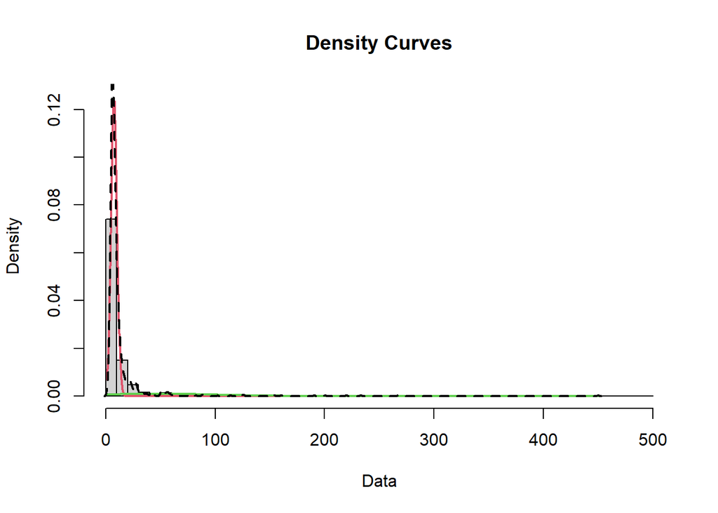

```r
plot(mixmdl,which=2,breaks=seq(0,500,by=10))
lines(density(isis), lty=2, lwd=2)
```

And a summary of the fitted two part mixture

```r
kable(summary(mixmdl))
```

```
## summary of normalmixEM object:
##          comp 1    comp 2
## lambda 0.851094  0.148906
## mu     7.491447 49.135643
## sigma  2.702792 59.973751
## loglik at estimate:  -3408.058
```

```r
p.mix<-mixmdl$lambda
means.mix<-mixmdl$mu
sds.mix<-mixmdl$sigma
```

```r
crs.by.indiv$dur3<-with(crs.by.indiv,dur2+(means.mix[2]/60))
crs.by.indiv$cr2<-with(crs.by.indiv,sounds/dur3)
```

```r
cr.new<-mean(crs.by.indiv$cr2)
ci.cr2<-t.test(crs.by.indiv$cr2)$conf.int
cv.cr2<-100*(sd(crs.by.indiv$cr2)/sqrt(nrow(crs.by.indiv)))/mean(crs.by.indiv$cr2)
```

This would then lead to an estimate of cue rate of 3.87, with 95% CI of 3.26-4.47. The coefficient of variation is 7.78 %.

The confidence interval above does not propagate the uncertainty in estimating the mean of the $bbi$’s. To do so we incorporate a non-parametric bootstrap procedure, resampling the birds subjected to focal follows.

This leads to a point estimate of 3.87 with corresponding 95% CV of 3.26-4.51. This corresponds to a CV of 8.33.

Unfortunately, late in the game, we noticed that Gaussian mixtures are not sensible, because they assign considerable density to inadmissible values for cue rates, i.e. negative values for a quantity which must be strictly non-negative.

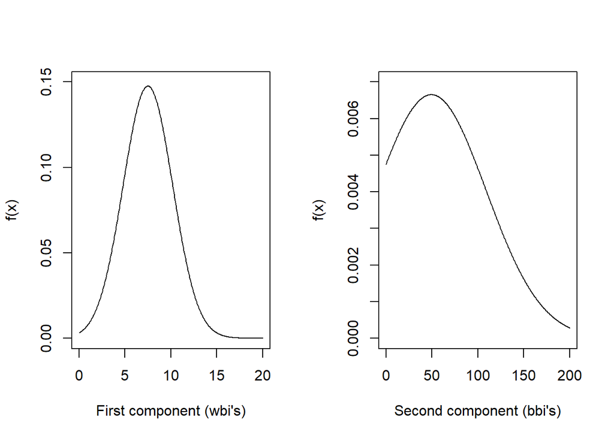

```r
par(mfrow=c(1,2))
xs<-seq(0,20,length=500)
plot(xs,dnorm(xs,mean=mixmdl$mu[1],sd=mixmdl$sigma[1]),type="l",xlab="First component (wbi's)",ylab="f(x)",ylim=c(0,0.15))
xs<-seq(0,200,length=500)
plot(xs,dnorm(xs,mean=mixmdl$mu[2],sd=mixmdl$sigma[2]),type="l",xlab="Second component (bbi's)",ylab="f(x)",ylim=c(0,0.007))
```

Unfortunately, implementations of Gamma mixtures, which might be perhaps a more sensible strictly non-negative distribution, do not converge using `mixtools::gammamixEM`

```r
#try gamma mixture
mixmdlGamma = gammamixEM(isis,k=2,lambda=mixmdl$lambda,alpha=mixmdl$mu,beta=1/mixmdl$mu)
```

[output not shown]

Hence, we investigated other, creative, ways of fitting such Gamma mixtures.

## Considering Gamma mixtures

The way we decided to fit the Gamma mixture involved realizing that the times between songs could be seen as the conceptual equivalent of coordinates in a conceptual displacement of individuals.

Models to fit animal movement data considering a step-length and turning-angle formulation are routinely used to fit Gamma mixtures to the step length distributions, where different distributions are conditional on the behavioural state the animals is in. Examples include R packages `momentuHMM` (McClintock & Michelot (2018)) and `moveHMM` (Michelot *et al.* (2016)).

Here we use the latter to fit a Gamma mixture with two states, equivalent to the $wbi$’s and the $bbi$’s. To do so, we simply have to re-shape our data to look like what `moveHMM` would expect for animal coordinates from movement data. These include the ($x$,$y$)coordinates of what would have been the successive locations of individuals. In particular, that means defining a series of step lengths where all animals are considered to start at position (0,0), and then move straight up north (without loss of generality, but that means we can keep the $x$ coordinate constant and just change the $y$ coordinate according to the song times of each bird), with each new “location” y coordinate corresponding to the time of the next sound detection.

We first reshape the data accordingly.

```r
preMyData4MoveData <- data.frame(ID=indivs,x=0,y=isis)
# Adding the 0,0 coordinate to represent the start, since the first observed time already corresponds to a first "step"
# which would otherwise be ignored
MyData4MoveData<-data.frame(ID=integer(),x=integer(),y=integer())
for(i in 1:max(preMyData4MoveData$ID)){
  #select the current ID
  #set it's "initial location" at 0,0
  row1temp<-data.frame(ID=i,x=0,y=0)
  temp <- preMyData4MoveData[preMyData4MoveData$ID==i,]
  temp <- rbind(row1temp,temp)
  #transform the isi into a proper new coordinate, form which prepData can compute the correct step length
  temp$y=cumsum(temp$y)
  MyData4MoveData<-rbind(MyData4MoveData,temp)
}
#MyMoveData <- moveData(MyData4MoveData)
MyMoveData <- prepData(MyData4MoveData,type="UTM")
```

Then we fit the model using `moveHMM::fitHMM`

```r
fitGamma1<-fitHMM(MyMoveData,
  nbStates=2,
  stepPar0=c(2,2,3,3),
  anglePar0 = NULL,
  beta0 = NULL,
  delta0 = NULL,
  formula = ~1,
  stepDist = "gamma",
  angleDist = "none")
```

We can now take a look at the results

```r
fitGamma1
```

```
## Value of the maximum log-likelihood: -3171.285
##
## Step length parameters:
## ----------------------
##       state 1  state 2
## mean 38.01998 7.360200
## sd   36.81585 2.482135
##
##
## Regression coeffs for the transition probabilities:
## --------------------------------------------------
##               1 -> 2    2 -> 1
## intercept -0.8483846 -2.421396
##
## Transition probability matrix:
## -----------------------------
##           [,1]      [,2]
## [1,] 0.7002282 0.2997718
## [2,] 0.0815556 0.9184444
##
## Initial distribution:
## --------------------
## [1] 0.4338908 0.5661092
```

and describe the distribution of the corresponding Gamma for each state, which naturally by construction no longer included density mass at negative values.

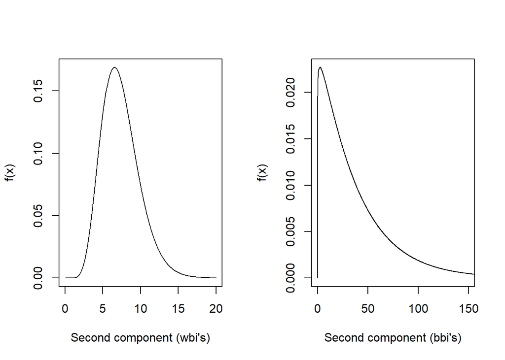

```r
par(mfrow=c(1,2))
xseqs<-seq(0,20,by=0.1)
plot(xseqs,dgamma(xseqs,shape=fitGamma1$mle$stepPar[1,2]^2/fitGamma1$mle$stepPar[2,2]^2,scale=fitGamma1$mle$stepPar[2,2]^2/fitGamma1$mle$stepPar[1,2]),type="l",ylab="f(x)",xlab="Second component (wbi's)")
xseqs<-seq(0,200,by=0.1)
plot(xseqs,dgamma(xseqs,shape=fitGamma1$mle$stepPar[1,1]^2/fitGamma1$mle$stepPar[2,1]^2,scale=fitGamma1$mle$stepPar[2,1]^2/fitGamma1$mle$stepPar[1,1]),type="l",xlim=c(0,150),ylab="f(x)",xlab="Second component (bbi's)")
```

Based on this the mean of the $bbi$’s is 38.02 with a standard deviation of 36.82 while the mean of the $wbi$’s is 7.36 with a standard deviation of 2.48. Just as before, we can now estimate the corresponding cue rate

```r
crs.by.indiv$dur3G<-with(crs.by.indiv,dur2+(fitGamma1$mle$stepPar[1,1]/60))
crs.by.indiv$cr2G<-with(crs.by.indiv,sounds/dur3G)
```

```r
cr.newG<-mean(crs.by.indiv$cr2G)
ci.cr2G<-t.test(crs.by.indiv$cr2G)$conf.int
cv.cr2G<-100*(sd(crs.by.indiv$cr2G)/sqrt(nrow(crs.by.indiv)))/mean(crs.by.indiv$cr2G)
```

This would then lead to an estimate of cue rate of 4.07, with 95% CI of 3.45-4.7. The coefficient of variation is 7.61 %. This confidence interval does not propagate the uncertainty in estimating the mean of the $bbi$’s. To do so we incorporate a non-parametric bootstrap procedure, resampling the birds subjected to focal follows.

This leads to a point estimate of 4.07 with corresponding 95% CV of 3.29-4.56. This corresponds to a CV of 7.81.

We can actually estimate the proportion of time spent on each state. Note here cannot be seen as time, because the HMM assumes time steps of the same unit length. We can think of it as how many $wbi$’s to $bbi$’s are produced, say.

```r
mystat<-stationary(fitGamma1,covs = data.frame(0))
```

It seems like for each $bbi$ there are 3.6756744 about $wbi$’s produced, or in other words, that a song burst includes about 4.6756744 sounds.

# About moveHMM beating mixtools

even if we start mixtools at the MLE’s from moveHMM, the code does not converge. Weird, very weird, but hey…

```r
#try gamma mixture
 mixmdlGamma = gammamixEM(isis,k=2,lambda=mystat,alpha=fitGamma1$mle$stepPar[1,]^2/fitGamma1$mle$stepPar[2,]^2,beta=fitGamma1$mle$stepPar[2,]^2/fitGamma1$mle$stepPar[1,])
```

```
## number of iterations= 21
## WARNING! NOT CONVERGENT!
## number of iterations= 1000
```

# A bug for Théo?

```r
fitGammaBug<-fitHMM(MyMoveData,
  nbStates=2,
  stepPar0=c(2,2,3,3),
  anglePar0 = NULL,
  beta0 = NULL,
  delta0 = NULL,
  formula = ~ID,
  stepDist = "gamma",
  angleDist = "none")
```

# Saving an object to frontload in the main paper document

Here we save a workspace which contains all the object to derive results required to allow the paper main document to be compiled.

```r
save.image(file="results4paper.Rdata")
```

Sourcing this workspace `results4paper.Rdata` in `Marquesetal2023cuerate4birds.Rmd` allows to generate all the figures within the manuscript.

# References

McClintock, B.T. & Michelot, T. (2018). [momentuHMM: R package for generalized hidden markov models of animal movement](https://doi.org/10.1111/2041-210x.12995). *Methods in Ecology and Evolution*.

Michelot, T., Langrock, R. & Patterson, T.A. (2016). moveHMM: An R package for the statistical modelling of animal movement data using hidden markov models. *Methods in Ecology and Evolution*, **7**, 1308–1315. Retrieved from http://dx.doi.org/10.1111/2041-210X.12578